# Risk Factor Analysis

## Outcome Variable

**Outcome Variable:** whz

## Predictor Variables

**Intervention Variable:** hfoodsec

**Adjustment Set:**

- arm
- sex
- W_mage
- meducyrs
- feducyrs
- hhwealth_quart
- vagbrth
- W_nrooms
- W_nchldlt5
- brthmon
- W_parity
- impfloor
- impsan
- safeh20
- delta_W_mage
- delta_meducyrs
- delta_feducyrs
- delta_hhwealth_quart
- delta_vagbrth
- delta_W_nrooms
- delta_W_nchldlt5
- delta_brthmon
- delta_W_parity
- delta_impfloor
- delta_impsan
- delta_safeh20

## Stratifying Variables

The analysis was stratified on these variable(s):

- agecat
- studyid
- country

## Data Summary

| agecat | studyid | country | hfoodsec | n_cell | n | outcome_variable |
| --- | --- | --- | --- | --- | --- | --- |
| Birth | ki0047075b-MAL-ED | BANGLADESH | Food Secure | 138 | 162 | whz |
| Birth | ki0047075b-MAL-ED | BANGLADESH | Mildly Food Insecure | 3 | 162 | whz |
| Birth | ki0047075b-MAL-ED | BANGLADESH | Food Insecure | 21 | 162 | whz |
| Birth | ki0047075b-MAL-ED | BRAZIL | Food Secure | 0 | 26 | whz |
| Birth | ki0047075b-MAL-ED | BRAZIL | Mildly Food Insecure | 4 | 26 | whz |
| Birth | ki0047075b-MAL-ED | BRAZIL | Food Insecure | 22 | 26 | whz |
| Birth | ki0047075b-MAL-ED | INDIA | Food Secure | 32 | 35 | whz |
| Birth | ki0047075b-MAL-ED | INDIA | Mildly Food Insecure | 1 | 35 | whz |
| Birth | ki0047075b-MAL-ED | INDIA | Food Insecure | 2 | 35 | whz |
| Birth | ki0047075b-MAL-ED | NEPAL | Food Secure | 10 | 14 | whz |
| Birth | ki0047075b-MAL-ED | NEPAL | Mildly Food Insecure | 1 | 14 | whz |
| Birth | ki0047075b-MAL-ED | NEPAL | Food Insecure | 3 | 14 | whz |
| Birth | ki0047075b-MAL-ED | PERU | Food Secure | 23 | 89 | whz |
| Birth | ki0047075b-MAL-ED | PERU | Mildly Food Insecure | 22 | 89 | whz |
| Birth | ki0047075b-MAL-ED | PERU | Food Insecure | 44 | 89 | whz |
| Birth | ki0047075b-MAL-ED | SOUTH AFRICA | Food Secure | 45 | 87 | whz |
| Birth | ki0047075b-MAL-ED | SOUTH AFRICA | Mildly Food Insecure | 9 | 87 | whz |
| Birth | ki0047075b-MAL-ED | SOUTH AFRICA | Food Insecure | 33 | 87 | whz |
| Birth | ki1017093-NIH-Birth | BANGLADESH | Food Secure | 86 | 575 | whz |
| Birth | ki1017093-NIH-Birth | BANGLADESH | Mildly Food Insecure | 453 | 575 | whz |
| Birth | ki1017093-NIH-Birth | BANGLADESH | Food Insecure | 36 | 575 | whz |
| Birth | ki1017093c-NIH-Crypto | BANGLADESH | Food Secure | 429 | 707 | whz |
| Birth | ki1017093c-NIH-Crypto | BANGLADESH | Mildly Food Insecure | 199 | 707 | whz |
| Birth | ki1017093c-NIH-Crypto | BANGLADESH | Food Insecure | 79 | 707 | whz |
| Birth | ki1113344-GMS-Nepal | NEPAL | Food Secure | 442 | 620 | whz |
| Birth | ki1113344-GMS-Nepal | NEPAL | Mildly Food Insecure | 100 | 620 | whz |
| Birth | ki1113344-GMS-Nepal | NEPAL | Food Insecure | 78 | 620 | whz |
| Birth | kiGH5241-JiVitA-3 | BANGLADESH | Food Secure | 5797 | 11763 | whz |
| Birth | kiGH5241-JiVitA-3 | BANGLADESH | Mildly Food Insecure | 3947 | 11763 | whz |
| Birth | kiGH5241-JiVitA-3 | BANGLADESH | Food Insecure | 2019 | 11763 | whz |

[output cut: 69 more lines]

The following strata were considered:

- agecat: 24 months, studyid: ki0047075b-MAL-ED, country: BANGLADESH
- agecat: 24 months, studyid: ki0047075b-MAL-ED, country: BRAZIL
- agecat: 24 months, studyid: ki0047075b-MAL-ED, country: INDIA
- agecat: 24 months, studyid: ki0047075b-MAL-ED, country: NEPAL
- agecat: 24 months, studyid: ki0047075b-MAL-ED, country: PERU
- agecat: 24 months, studyid: ki0047075b-MAL-ED, country: SOUTH AFRICA
- agecat: 24 months, studyid: ki1017093-NIH-Birth, country: BANGLADESH
- agecat: 24 months, studyid: ki1017093c-NIH-Crypto, country: BANGLADESH
- agecat: 24 months, studyid: ki1113344-GMS-Nepal, country: NEPAL
- agecat: 24 months, studyid: kiGH5241-JiVitA-3, country: BANGLADESH
- agecat: 24 months, studyid: kiGH5241-JiVitA-4, country: BANGLADESH
- agecat: 6 months, studyid: ki0047075b-MAL-ED, country: BANGLADESH
- agecat: 6 months, studyid: ki0047075b-MAL-ED, country: BRAZIL
- agecat: 6 months, studyid: ki0047075b-MAL-ED, country: INDIA
- agecat: 6 months, studyid: ki0047075b-MAL-ED, country: NEPAL
- agecat: 6 months, studyid: ki0047075b-MAL-ED, country: PERU
- agecat: 6 months, studyid: ki0047075b-MAL-ED, country: SOUTH AFRICA
- agecat: 6 months, studyid: ki1017093-NIH-Birth, country: BANGLADESH
- agecat: 6 months, studyid: ki1017093c-NIH-Crypto, country: BANGLADESH
- agecat: 6 months, studyid: ki1113344-GMS-Nepal, country: NEPAL
- agecat: 6 months, studyid: kiGH5241-JiVitA-3, country: BANGLADESH
- agecat: 6 months, studyid: kiGH5241-JiVitA-4, country: BANGLADESH
- agecat: Birth, studyid: ki0047075b-MAL-ED, country: BANGLADESH
- agecat: Birth, studyid: ki0047075b-MAL-ED, country: BRAZIL
- agecat: Birth, studyid: ki0047075b-MAL-ED, country: INDIA
- agecat: Birth, studyid: ki0047075b-MAL-ED, country: NEPAL
- agecat: Birth, studyid: ki0047075b-MAL-ED, country: PERU
- agecat: Birth, studyid: ki0047075b-MAL-ED, country: SOUTH AFRICA
- agecat: Birth, studyid: ki1017093-NIH-Birth, country: BANGLADESH
- agecat: Birth, studyid: ki1017093c-NIH-Crypto, country: BANGLADESH
- agecat: Birth, studyid: ki1113344-GMS-Nepal, country: NEPAL
- agecat: Birth, studyid: kiGH5241-JiVitA-3, country: BANGLADESH
- agecat: Birth, studyid: kiGH5241-JiVitA-4, country: BANGLADESH

### Dropped Strata

Some strata were dropped due to rare outcomes:

- agecat: Birth, studyid: ki0047075b-MAL-ED, country: BANGLADESH
- agecat: Birth, studyid: ki0047075b-MAL-ED, country: BRAZIL
- agecat: Birth, studyid: ki0047075b-MAL-ED, country: INDIA
- agecat: Birth, studyid: ki0047075b-MAL-ED, country: NEPAL
- agecat: 6 months, studyid: ki0047075b-MAL-ED, country: BANGLADESH
- agecat: 6 months, studyid: ki0047075b-MAL-ED, country: BRAZIL
- agecat: 24 months, studyid: ki0047075b-MAL-ED, country: BANGLADESH
- agecat: 24 months, studyid: ki0047075b-MAL-ED, country: BRAZIL

## Methods Detail

We’re interested in the causal parameters $E[Y_a]$ for all values of $a \in \mathcal{A}$. These parameters represent the mean outcome if, possibly contrary to fact, we intervened to set all units to have $A=a$. Under the randomization and positivity assumptions, these are identified by the statistical parameters $\psi_a=E_W[E_{Y|A,W}(Y|A=a,W)]$. In addition, we’re interested in the mean of $Y$, $E[Y]$ under no intervention (the observed mean). We will estimate these parameters by using SuperLearner to fit the relevant likelihood factors – $E_{Y|A,W}(Y|A=a,W)$ and $p(A=a|W)$, and then updating our likelihood fit using a joint TMLE.

For unadjusted analyses ($W=\{\}$), initial likelihoods were estimated using Lrnr_glm to estimate the simple $E(Y|A)$ and Lrnr_mean to estimate $p(A)$. For adjusted analyses, a small library containing Lrnr_glmnet, Lrnr_xgboost, and Lrnr_mean was used.

Having estimated these parameters, we will then use the delta method to estimate relative risks and attributable risks relative to a prespecified baseline level of $A$.

# Results Detail

## Results Plots

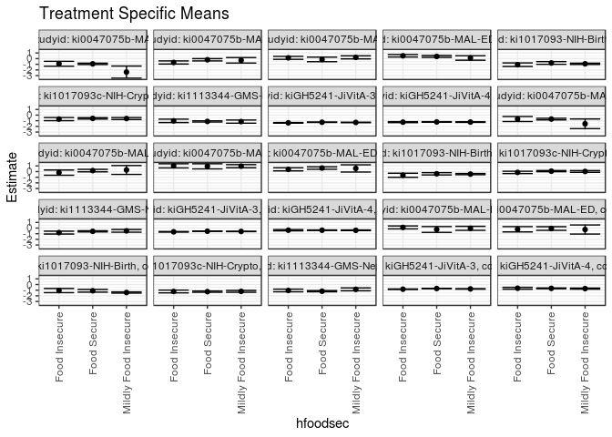

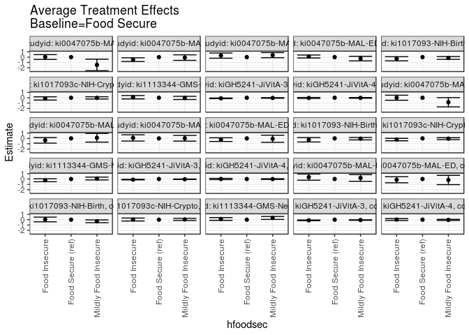

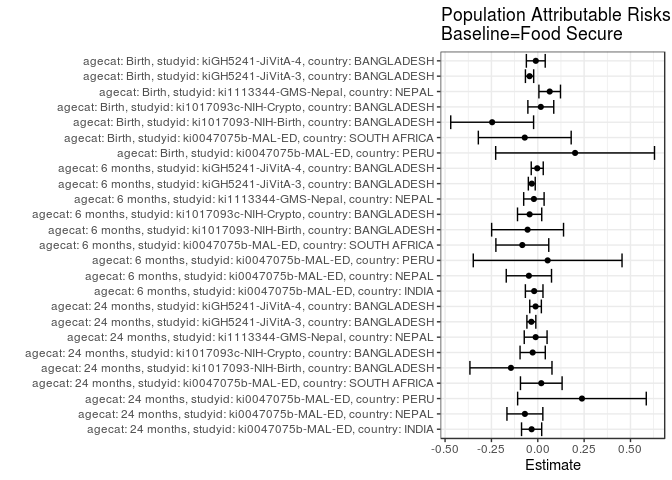

## Results Table

### Parameter: TSM

| agecat | studyid | country | intervention_level | baseline_level | estimate | ci_lower | ci_upper |
| --- | --- | --- | --- | --- | --- | --- | --- |
| Birth | ki0047075b-MAL-ED | PERU | Food Secure | NA | -0.2495392 | -0.7641634 | 0.2650850 |
| Birth | ki0047075b-MAL-ED | PERU | Mildly Food Insecure | NA | -0.0463245 | -0.3957410 | 0.3030919 |
| Birth | ki0047075b-MAL-ED | PERU | Food Insecure | NA | 0.1091703 | -0.1550626 | 0.3734033 |
| Birth | ki0047075b-MAL-ED | SOUTH AFRICA | Food Secure | NA | -0.0800000 | -0.4003913 | 0.2403913 |
| Birth | ki0047075b-MAL-ED | SOUTH AFRICA | Mildly Food Insecure | NA | -0.2611111 | -1.0678216 | 0.5455994 |
| Birth | ki0047075b-MAL-ED | SOUTH AFRICA | Food Insecure | NA | -0.2157576 | -0.6840291 | 0.2525139 |
| Birth | ki1017093-NIH-Birth | BANGLADESH | Food Secure | NA | -1.1038872 | -1.3446905 | -0.8630840 |
| Birth | ki1017093-NIH-Birth | BANGLADESH | Mildly Food Insecure | NA | -1.4115916 | -1.5183806 | -1.3048026 |
| Birth | ki1017093-NIH-Birth | BANGLADESH | Food Insecure | NA | -1.0688042 | -1.4381007 | -0.6995077 |
| Birth | ki1017093c-NIH-Crypto | BANGLADESH | Food Secure | NA | -1.2605175 | -1.3713198 | -1.1497152 |
| Birth | ki1017093c-NIH-Crypto | BANGLADESH | Mildly Food Insecure | NA | -1.2082740 | -1.3732131 | -1.0433349 |
| Birth | ki1017093c-NIH-Crypto | BANGLADESH | Food Insecure | NA | -1.2308705 | -1.4797697 | -0.9819712 |
| Birth | ki1113344-GMS-Nepal | NEPAL | Food Secure | NA | -1.1808138 | -1.2844141 | -1.0772135 |
| Birth | ki1113344-GMS-Nepal | NEPAL | Mildly Food Insecure | NA | -0.8534455 | -1.1097102 | -0.5971807 |
| Birth | ki1113344-GMS-Nepal | NEPAL | Food Insecure | NA | -1.0505350 | -1.2878677 | -0.8132023 |
| Birth | kiGH5241-JiVitA-3 | BANGLADESH | Food Secure | NA | -0.7064923 | -0.7376423 | -0.6753422 |
| Birth | kiGH5241-JiVitA-3 | BANGLADESH | Mildly Food Insecure | NA | -0.7751015 | -0.8138994 | -0.7363036 |
| Birth | kiGH5241-JiVitA-3 | BANGLADESH | Food Insecure | NA | -0.8280566 | -0.8780555 | -0.7780577 |
| Birth | kiGH5241-JiVitA-4 | BANGLADESH | Food Secure | NA | -0.6790983 | -0.7460616 | -0.6121350 |
| Birth | kiGH5241-JiVitA-4 | BANGLADESH | Mildly Food Insecure | NA | -0.7204956 | -0.8089797 | -0.6320114 |
| Birth | kiGH5241-JiVitA-4 | BANGLADESH | Food Insecure | NA | -0.6611182 | -0.8264164 | -0.4958200 |
| 6 months | ki0047075b-MAL-ED | INDIA | Food Secure | NA | -0.7025789 | -0.8453715 | -0.5597864 |
| 6 months | ki0047075b-MAL-ED | INDIA | Mildly Food Insecure | NA | -1.5420000 | -2.3989104 | -0.6850896 |
| 6 months | ki0047075b-MAL-ED | INDIA | Food Insecure | NA | -0.6978922 | -1.1435259 | -0.2522584 |
| 6 months | ki0047075b-MAL-ED | NEPAL | Food Secure | NA | 0.1757333 | -0.0434639 | 0.3949304 |
| 6 months | ki0047075b-MAL-ED | NEPAL | Mildly Food Insecure | NA | 0.2841139 | -0.4984382 | 1.0666659 |
| 6 months | ki0047075b-MAL-ED | NEPAL | Food Insecure | NA | -0.1884393 | -0.6531778 | 0.2762991 |
| 6 months | ki0047075b-MAL-ED | PERU | Food Secure | NA | 0.9286771 | 0.4733876 | 1.3839665 |
| 6 months | ki0047075b-MAL-ED | PERU | Mildly Food Insecure | NA | 0.9527340 | 0.6749754 | 1.2304926 |
| 6 months | ki0047075b-MAL-ED | PERU | Food Insecure | NA | 1.0177739 | 0.6514559 | 1.3840919 |
| 6 months | ki0047075b-MAL-ED | SOUTH AFRICA | Food Secure | NA | 0.6262574 | 0.4113446 | 0.8411703 |
| 6 months | ki0047075b-MAL-ED | SOUTH AFRICA | Mildly Food Insecure | NA | 0.5569912 | -0.0813569 | 1.1953393 |
| 6 months | ki0047075b-MAL-ED | SOUTH AFRICA | Food Insecure | NA | 0.4000551 | 0.1272673 | 0.6728428 |
| 6 months | ki1017093-NIH-Birth | BANGLADESH | Food Secure | NA | -0.3924467 | -0.5947157 | -0.1901778 |
| 6 months | ki1017093-NIH-Birth | BANGLADESH | Mildly Food Insecure | NA | -0.4447832 | -0.5498987 | -0.3396678 |
| 6 months | ki1017093-NIH-Birth | BANGLADESH | Food Insecure | NA | -0.6520373 | -1.0112725 | -0.2928021 |
| 6 months | ki1017093c-NIH-Crypto | BANGLADESH | Food Secure | NA | 0.0737441 | -0.0318562 | 0.1793444 |
| 6 months | ki1017093c-NIH-Crypto | BANGLADESH | Mildly Food Insecure | NA | 0.0231162 | -0.1300346 | 0.1762670 |
| 6 months | ki1017093c-NIH-Crypto | BANGLADESH | Food Insecure | NA | -0.1443843 | -0.3488794 | 0.0601108 |
| 6 months | ki1113344-GMS-Nepal | NEPAL | Food Secure | NA | -0.5809467 | -0.6877199 | -0.4741735 |
| 6 months | ki1113344-GMS-Nepal | NEPAL | Mildly Food Insecure | NA | -0.4920706 | -0.7300098 | -0.2541313 |
| 6 months | ki1113344-GMS-Nepal | NEPAL | Food Insecure | NA | -0.8076197 | -1.0596379 | -0.5556015 |
| 6 months | kiGH5241-JiVitA-3 | BANGLADESH | Food Secure | NA | -0.5609281 | -0.5885031 | -0.5333531 |
| 6 months | kiGH5241-JiVitA-3 | BANGLADESH | Mildly Food Insecure | NA | -0.6008652 | -0.6320236 | -0.5697069 |
| 6 months | kiGH5241-JiVitA-3 | BANGLADESH | Food Insecure | NA | -0.6672201 | -0.7148452 | -0.6195950 |
| 6 months | kiGH5241-JiVitA-4 | BANGLADESH | Food Secure | NA | -0.3866378 | -0.4351590 | -0.3381165 |
| 6 months | kiGH5241-JiVitA-4 | BANGLADESH | Mildly Food Insecure | NA | -0.3968542 | -0.4548283 | -0.3388801 |
| 6 months | kiGH5241-JiVitA-4 | BANGLADESH | Food Insecure | NA | -0.3816250 | -0.4922259 | -0.2710240 |
| 24 months | ki0047075b-MAL-ED | INDIA | Food Secure | NA | -0.9256316 | -1.0440690 | -0.8071941 |
| 24 months | ki0047075b-MAL-ED | INDIA | Mildly Food Insecure | NA | -2.3840000 | -3.4554070 | -1.3125930 |
| 24 months | ki0047075b-MAL-ED | INDIA | Food Insecure | NA | -0.9111765 | -1.3418053 | -0.4805476 |
| 24 months | ki0047075b-MAL-ED | NEPAL | Food Secure | NA | -0.2035569 | -0.4048872 | -0.0022266 |
| 24 months | ki0047075b-MAL-ED | NEPAL | Mildly Food Insecure | NA | -0.2958346 | -0.7780623 | 0.1863931 |
| 24 months | ki0047075b-MAL-ED | NEPAL | Food Insecure | NA | -0.6790259 | -0.9559936 | -0.4020581 |
| 24 months | ki0047075b-MAL-ED | PERU | Food Secure | NA | -0.1400455 | -0.5434352 | 0.2633443 |
| 24 months | ki0047075b-MAL-ED | PERU | Mildly Food Insecure | NA | 0.2249291 | -0.0435939 | 0.4934521 |
| 24 months | ki0047075b-MAL-ED | PERU | Food Insecure | NA | 0.1386749 | -0.1227015 | 0.4000514 |
| 24 months | ki0047075b-MAL-ED | SOUTH AFRICA | Food Secure | NA | 0.3891265 | 0.2204964 | 0.5577565 |
| 24 months | ki0047075b-MAL-ED | SOUTH AFRICA | Mildly Food Insecure | NA | 0.1131224 | -0.2804030 | 0.5066478 |
| 24 months | ki0047075b-MAL-ED | SOUTH AFRICA | Food Insecure | NA | 0.5060803 | 0.2859748 | 0.7261857 |
| 24 months | ki1017093-NIH-Birth | BANGLADESH | Food Secure | NA | -0.7669042 | -1.0054679 | -0.5283405 |
| 24 months | ki1017093-NIH-Birth | BANGLADESH | Mildly Food Insecure | NA | -0.9181485 | -1.0324813 | -0.8038157 |
| 24 months | ki1017093-NIH-Birth | BANGLADESH | Food Insecure | NA | -1.0715433 | -1.3859101 | -0.7571766 |
| 24 months | ki1017093c-NIH-Crypto | BANGLADESH | Food Secure | NA | -0.5828091 | -0.7074789 | -0.4581394 |
| 24 months | ki1017093c-NIH-Crypto | BANGLADESH | Mildly Food Insecure | NA | -0.6097223 | -0.7849280 | -0.4345166 |
| 24 months | ki1017093c-NIH-Crypto | BANGLADESH | Food Insecure | NA | -0.7067858 | -0.9851901 | -0.4283815 |
| 24 months | ki1113344-GMS-Nepal | NEPAL | Food Secure | NA | -1.1190694 | -1.2248340 | -1.0133048 |
| 24 months | ki1113344-GMS-Nepal | NEPAL | Mildly Food Insecure | NA | -1.1516278 | -1.4285980 | -0.8746576 |
| 24 months | ki1113344-GMS-Nepal | NEPAL | Food Insecure | NA | -1.0204992 | -1.3191358 | -0.7218626 |
| 24 months | kiGH5241-JiVitA-3 | BANGLADESH | Food Secure | NA | -1.2642274 | -1.2975034 | -1.2309514 |
| 24 months | kiGH5241-JiVitA-3 | BANGLADESH | Mildly Food Insecure | NA | -1.2985179 | -1.3402825 | -1.2567532 |
| 24 months | kiGH5241-JiVitA-3 | BANGLADESH | Food Insecure | NA | -1.3706761 | -1.4232829 | -1.3180693 |
| 24 months | kiGH5241-JiVitA-4 | BANGLADESH | Food Secure | NA | -1.2123770 | -1.2569304 | -1.1678236 |
| 24 months | kiGH5241-JiVitA-4 | BANGLADESH | Mildly Food Insecure | NA | -1.2338769 | -1.2894134 | -1.1783404 |
| 24 months | kiGH5241-JiVitA-4 | BANGLADESH | Food Insecure | NA | -1.2476341 | -1.3282007 | -1.1670675 |

### Parameter: E(Y)

| agecat | studyid | country | intervention_level | baseline_level | estimate | ci_lower | ci_upper |
| --- | --- | --- | --- | --- | --- | --- | --- |
| Birth | ki0047075b-MAL-ED | PERU | NA | NA | -0.0483146 | -0.2475806 | 0.1509514 |
| Birth | ki0047075b-MAL-ED | SOUTH AFRICA | NA | NA | -0.1502299 | -0.4075620 | 0.1071022 |
| Birth | ki1017093-NIH-Birth | BANGLADESH | NA | NA | -1.3499217 | -1.4444634 | -1.2553801 |
| Birth | ki1017093c-NIH-Crypto | BANGLADESH | NA | NA | -1.2441513 | -1.3281130 | -1.1601897 |
| Birth | ki1113344-GMS-Nepal | NEPAL | NA | NA | -1.1165161 | -1.2055683 | -1.0274639 |
| Birth | kiGH5241-JiVitA-3 | BANGLADESH | NA | NA | -0.7508875 | -0.7730765 | -0.7286985 |
| Birth | kiGH5241-JiVitA-4 | BANGLADESH | NA | NA | -0.6898154 | -0.7422632 | -0.6373675 |
| 6 months | ki0047075b-MAL-ED | INDIA | NA | NA | -0.7220008 | -0.8576809 | -0.5863207 |
| 6 months | ki0047075b-MAL-ED | NEPAL | NA | NA | 0.1277734 | -0.0649431 | 0.3204900 |
| 6 months | ki0047075b-MAL-ED | PERU | NA | NA | 0.9819369 | 0.7674415 | 1.1964324 |
| 6 months | ki0047075b-MAL-ED | SOUTH AFRICA | NA | NA | 0.5429020 | 0.3813518 | 0.7044523 |
| 6 months | ki1017093-NIH-Birth | BANGLADESH | NA | NA | -0.4474038 | -0.5378167 | -0.3569909 |
| 6 months | ki1017093c-NIH-Crypto | BANGLADESH | NA | NA | 0.0297622 | -0.0491685 | 0.1086930 |
| 6 months | ki1113344-GMS-Nepal | NEPAL | NA | NA | -0.6018803 | -0.6892284 | -0.5145323 |
| 6 months | kiGH5241-JiVitA-3 | BANGLADESH | NA | NA | -0.5932301 | -0.6127836 | -0.5736767 |
| 6 months | kiGH5241-JiVitA-4 | BANGLADESH | NA | NA | -0.3895527 | -0.4270314 | -0.3520739 |
| 24 months | ki0047075b-MAL-ED | INDIA | NA | NA | -0.9588679 | -1.0774868 | -0.8402491 |
| 24 months | ki0047075b-MAL-ED | NEPAL | NA | NA | -0.2730469 | -0.4358169 | -0.1102769 |
| 24 months | ki0047075b-MAL-ED | PERU | NA | NA | 0.0982009 | -0.0794754 | 0.2758773 |
| 24 months | ki0047075b-MAL-ED | SOUTH AFRICA | NA | NA | 0.4080227 | 0.2828348 | 0.5332106 |
| 24 months | ki1017093-NIH-Birth | BANGLADESH | NA | NA | -0.9115790 | -1.0095022 | -0.8136559 |
| 24 months | ki1017093c-NIH-Crypto | BANGLADESH | NA | NA | -0.6103502 | -0.7050157 | -0.5156847 |
| 24 months | ki1113344-GMS-Nepal | NEPAL | NA | NA | -1.1304997 | -1.2205265 | -1.0404728 |
| 24 months | kiGH5241-JiVitA-3 | BANGLADESH | NA | NA | -1.2988352 | -1.3224626 | -1.2752078 |
| 24 months | kiGH5241-JiVitA-4 | BANGLADESH | NA | NA | -1.2243590 | -1.2566569 | -1.1920612 |

### Parameter: ATE

| agecat | studyid | country | intervention_level | baseline_level | estimate | ci_lower | ci_upper |
| --- | --- | --- | --- | --- | --- | --- | --- |
| Birth | ki0047075b-MAL-ED | PERU | Food Secure | Food Secure | 0.0000000 | 0.0000000 | 0.0000000 |
| Birth | ki0047075b-MAL-ED | PERU | Mildly Food Insecure | Food Secure | 0.2032147 | -0.4221524 | 0.8285818 |
| Birth | ki0047075b-MAL-ED | PERU | Food Insecure | Food Secure | 0.3587095 | -0.2244011 | 0.9418201 |
| Birth | ki0047075b-MAL-ED | SOUTH AFRICA | Food Secure | Food Secure | 0.0000000 | 0.0000000 | 0.0000000 |
| Birth | ki0047075b-MAL-ED | SOUTH AFRICA | Mildly Food Insecure | Food Secure | -0.1811111 | -1.0491159 | 0.6868937 |
| Birth | ki0047075b-MAL-ED | SOUTH AFRICA | Food Insecure | Food Secure | -0.1357576 | -0.7031452 | 0.4316301 |
| Birth | ki1017093-NIH-Birth | BANGLADESH | Food Secure | Food Secure | 0.0000000 | 0.0000000 | 0.0000000 |
| Birth | ki1017093-NIH-Birth | BANGLADESH | Mildly Food Insecure | Food Secure | -0.3077044 | -0.5713696 | -0.0440391 |
| Birth | ki1017093-NIH-Birth | BANGLADESH | Food Insecure | Food Secure | 0.0350830 | -0.4057308 | 0.4758969 |
| Birth | ki1017093c-NIH-Crypto | BANGLADESH | Food Secure | Food Secure | 0.0000000 | 0.0000000 | 0.0000000 |
| Birth | ki1017093c-NIH-Crypto | BANGLADESH | Mildly Food Insecure | Food Secure | 0.0522435 | -0.1472172 | 0.2517042 |
| Birth | ki1017093c-NIH-Crypto | BANGLADESH | Food Insecure | Food Secure | 0.0296470 | -0.2439915 | 0.3032856 |
| Birth | ki1113344-GMS-Nepal | NEPAL | Food Secure | Food Secure | 0.0000000 | 0.0000000 | 0.0000000 |
| Birth | ki1113344-GMS-Nepal | NEPAL | Mildly Food Insecure | Food Secure | 0.3273683 | 0.0514009 | 0.6033358 |
| Birth | ki1113344-GMS-Nepal | NEPAL | Food Insecure | Food Secure | 0.1302788 | -0.1279870 | 0.3885447 |
| Birth | kiGH5241-JiVitA-3 | BANGLADESH | Food Secure | Food Secure | 0.0000000 | 0.0000000 | 0.0000000 |
| Birth | kiGH5241-JiVitA-3 | BANGLADESH | Mildly Food Insecure | Food Secure | -0.0686092 | -0.1168652 | -0.0203533 |
| Birth | kiGH5241-JiVitA-3 | BANGLADESH | Food Insecure | Food Secure | -0.1215643 | -0.1790233 | -0.0641054 |
| Birth | kiGH5241-JiVitA-4 | BANGLADESH | Food Secure | Food Secure | 0.0000000 | 0.0000000 | 0.0000000 |
| Birth | kiGH5241-JiVitA-4 | BANGLADESH | Mildly Food Insecure | Food Secure | -0.0413973 | -0.1512834 | 0.0684889 |
| Birth | kiGH5241-JiVitA-4 | BANGLADESH | Food Insecure | Food Secure | 0.0179801 | -0.1595273 | 0.1954876 |
| 6 months | ki0047075b-MAL-ED | INDIA | Food Secure | Food Secure | 0.0000000 | 0.0000000 | 0.0000000 |
| 6 months | ki0047075b-MAL-ED | INDIA | Mildly Food Insecure | Food Secure | -0.8394211 | -1.7081472 | 0.0293051 |
| 6 months | ki0047075b-MAL-ED | INDIA | Food Insecure | Food Secure | 0.0046868 | -0.4632653 | 0.4726389 |
| 6 months | ki0047075b-MAL-ED | NEPAL | Food Secure | Food Secure | 0.0000000 | 0.0000000 | 0.0000000 |
| 6 months | ki0047075b-MAL-ED | NEPAL | Mildly Food Insecure | Food Secure | 0.1083806 | -0.7040277 | 0.9207889 |
| 6 months | ki0047075b-MAL-ED | NEPAL | Food Insecure | Food Secure | -0.3641726 | -0.8801903 | 0.1518451 |
| 6 months | ki0047075b-MAL-ED | PERU | Food Secure | Food Secure | 0.0000000 | 0.0000000 | 0.0000000 |
| 6 months | ki0047075b-MAL-ED | PERU | Mildly Food Insecure | Food Secure | 0.0240570 | -0.5105607 | 0.5586746 |
| 6 months | ki0047075b-MAL-ED | PERU | Food Insecure | Food Secure | 0.0890969 | -0.5002293 | 0.6784230 |
| 6 months | ki0047075b-MAL-ED | SOUTH AFRICA | Food Secure | Food Secure | 0.0000000 | 0.0000000 | 0.0000000 |
| 6 months | ki0047075b-MAL-ED | SOUTH AFRICA | Mildly Food Insecure | Food Secure | -0.0692663 | -0.7427604 | 0.6042279 |
| 6 months | ki0047075b-MAL-ED | SOUTH AFRICA | Food Insecure | Food Secure | -0.2262024 | -0.5745810 | 0.1221763 |
| 6 months | ki1017093-NIH-Birth | BANGLADESH | Food Secure | Food Secure | 0.0000000 | 0.0000000 | 0.0000000 |
| 6 months | ki1017093-NIH-Birth | BANGLADESH | Mildly Food Insecure | Food Secure | -0.0523365 | -0.2811886 | 0.1765156 |
| 6 months | ki1017093-NIH-Birth | BANGLADESH | Food Insecure | Food Secure | -0.2595905 | -0.6728182 | 0.1536371 |
| 6 months | ki1017093c-NIH-Crypto | BANGLADESH | Food Secure | Food Secure | 0.0000000 | 0.0000000 | 0.0000000 |
| 6 months | ki1017093c-NIH-Crypto | BANGLADESH | Mildly Food Insecure | Food Secure | -0.0506279 | -0.2367998 | 0.1355440 |
| 6 months | ki1017093c-NIH-Crypto | BANGLADESH | Food Insecure | Food Secure | -0.2181284 | -0.4486272 | 0.0123704 |
| 6 months | ki1113344-GMS-Nepal | NEPAL | Food Secure | Food Secure | 0.0000000 | 0.0000000 | 0.0000000 |
| 6 months | ki1113344-GMS-Nepal | NEPAL | Mildly Food Insecure | Food Secure | 0.0888761 | -0.1719708 | 0.3497231 |
| 6 months | ki1113344-GMS-Nepal | NEPAL | Food Insecure | Food Secure | -0.2266730 | -0.5003789 | 0.0470328 |
| 6 months | kiGH5241-JiVitA-3 | BANGLADESH | Food Secure | Food Secure | 0.0000000 | 0.0000000 | 0.0000000 |
| 6 months | kiGH5241-JiVitA-3 | BANGLADESH | Mildly Food Insecure | Food Secure | -0.0399371 | -0.0808783 | 0.0010041 |
| 6 months | kiGH5241-JiVitA-3 | BANGLADESH | Food Insecure | Food Secure | -0.1062920 | -0.1588481 | -0.0537358 |
| 6 months | kiGH5241-JiVitA-4 | BANGLADESH | Food Secure | Food Secure | 0.0000000 | 0.0000000 | 0.0000000 |
| 6 months | kiGH5241-JiVitA-4 | BANGLADESH | Mildly Food Insecure | Food Secure | -0.0102164 | -0.0816625 | 0.0612297 |
| 6 months | kiGH5241-JiVitA-4 | BANGLADESH | Food Insecure | Food Secure | 0.0050128 | -0.1127186 | 0.1227442 |
| 24 months | ki0047075b-MAL-ED | INDIA | Food Secure | Food Secure | 0.0000000 | 0.0000000 | 0.0000000 |
| 24 months | ki0047075b-MAL-ED | INDIA | Mildly Food Insecure | Food Secure | -1.4583684 | -2.5363018 | -0.3804350 |
| 24 months | ki0047075b-MAL-ED | INDIA | Food Insecure | Food Secure | 0.0144551 | -0.4321640 | 0.4610742 |
| 24 months | ki0047075b-MAL-ED | NEPAL | Food Secure | Food Secure | 0.0000000 | 0.0000000 | 0.0000000 |
| 24 months | ki0047075b-MAL-ED | NEPAL | Mildly Food Insecure | Food Secure | -0.0922777 | -0.6143493 | 0.4297939 |
| 24 months | ki0047075b-MAL-ED | NEPAL | Food Insecure | Food Secure | -0.4754690 | -0.8181417 | -0.1327963 |
| 24 months | ki0047075b-MAL-ED | PERU | Food Secure | Food Secure | 0.0000000 | 0.0000000 | 0.0000000 |
| 24 months | ki0047075b-MAL-ED | PERU | Mildly Food Insecure | Food Secure | 0.3649746 | -0.1142860 | 0.8442351 |
| 24 months | ki0047075b-MAL-ED | PERU | Food Insecure | Food Secure | 0.2787204 | -0.2095448 | 0.7669856 |
| 24 months | ki0047075b-MAL-ED | SOUTH AFRICA | Food Secure | Food Secure | 0.0000000 | 0.0000000 | 0.0000000 |
| 24 months | ki0047075b-MAL-ED | SOUTH AFRICA | Mildly Food Insecure | Food Secure | -0.2760041 | -0.7039453 | 0.1519371 |
| 24 months | ki0047075b-MAL-ED | SOUTH AFRICA | Food Insecure | Food Secure | 0.1169538 | -0.1603645 | 0.3942721 |
| 24 months | ki1017093-NIH-Birth | BANGLADESH | Food Secure | Food Secure | 0.0000000 | 0.0000000 | 0.0000000 |
| 24 months | ki1017093-NIH-Birth | BANGLADESH | Mildly Food Insecure | Food Secure | -0.1512443 | -0.4159112 | 0.1134226 |
| 24 months | ki1017093-NIH-Birth | BANGLADESH | Food Insecure | Food Secure | -0.3046391 | -0.6992745 | 0.0899963 |
| 24 months | ki1017093c-NIH-Crypto | BANGLADESH | Food Secure | Food Secure | 0.0000000 | 0.0000000 | 0.0000000 |
| 24 months | ki1017093c-NIH-Crypto | BANGLADESH | Mildly Food Insecure | Food Secure | -0.0269131 | -0.2408809 | 0.1870547 |
| 24 months | ki1017093c-NIH-Crypto | BANGLADESH | Food Insecure | Food Secure | -0.1239766 | -0.4287424 | 0.1807891 |
| 24 months | ki1113344-GMS-Nepal | NEPAL | Food Secure | Food Secure | 0.0000000 | 0.0000000 | 0.0000000 |
| 24 months | ki1113344-GMS-Nepal | NEPAL | Mildly Food Insecure | Food Secure | -0.0325583 | -0.3293170 | 0.2642003 |
| 24 months | ki1113344-GMS-Nepal | NEPAL | Food Insecure | Food Secure | 0.0985702 | -0.2185799 | 0.4157204 |
| 24 months | kiGH5241-JiVitA-3 | BANGLADESH | Food Secure | Food Secure | 0.0000000 | 0.0000000 | 0.0000000 |
| 24 months | kiGH5241-JiVitA-3 | BANGLADESH | Mildly Food Insecure | Food Secure | -0.0342905 | -0.0866095 | 0.0180286 |
| 24 months | kiGH5241-JiVitA-3 | BANGLADESH | Food Insecure | Food Secure | -0.1064487 | -0.1670221 | -0.0458753 |
| 24 months | kiGH5241-JiVitA-4 | BANGLADESH | Food Secure | Food Secure | 0.0000000 | 0.0000000 | 0.0000000 |
| 24 months | kiGH5241-JiVitA-4 | BANGLADESH | Mildly Food Insecure | Food Secure | -0.0214999 | -0.0918985 | 0.0488986 |
| 24 months | kiGH5241-JiVitA-4 | BANGLADESH | Food Insecure | Food Secure | -0.0352571 | -0.1274007 | 0.0568865 |

### Parameter: PAR

| agecat | studyid | country | intervention_level | baseline_level | estimate | ci_lower | ci_upper |
| --- | --- | --- | --- | --- | --- | --- | --- |
| Birth | ki0047075b-MAL-ED | PERU | Food Secure | NA | 0.2012246 | -0.2270921 | 0.6295412 |
| Birth | ki0047075b-MAL-ED | SOUTH AFRICA | Food Secure | NA | -0.0702299 | -0.3205899 | 0.1801302 |
| Birth | ki1017093-NIH-Birth | BANGLADESH | Food Secure | NA | -0.2460345 | -0.4695125 | -0.0225565 |
| Birth | ki1017093c-NIH-Crypto | BANGLADESH | Food Secure | NA | 0.0163662 | -0.0534170 | 0.0861493 |
| Birth | ki1113344-GMS-Nepal | NEPAL | Food Secure | NA | 0.0642977 | 0.0061008 | 0.1224945 |
| Birth | kiGH5241-JiVitA-3 | BANGLADESH | Food Secure | NA | -0.0443953 | -0.0666302 | -0.0221603 |
| Birth | kiGH5241-JiVitA-4 | BANGLADESH | Food Secure | NA | -0.0107171 | -0.0615873 | 0.0401532 |
| 6 months | ki0047075b-MAL-ED | INDIA | Food Secure | NA | -0.0194218 | -0.0668687 | 0.0280250 |
| 6 months | ki0047075b-MAL-ED | NEPAL | Food Secure | NA | -0.0479598 | -0.1700185 | 0.0740989 |
| 6 months | ki0047075b-MAL-ED | PERU | Food Secure | NA | 0.0532599 | -0.3478840 | 0.4544037 |
| 6 months | ki0047075b-MAL-ED | SOUTH AFRICA | Food Secure | NA | -0.0833554 | -0.2259369 | 0.0592261 |
| 6 months | ki1017093-NIH-Birth | BANGLADESH | Food Secure | NA | -0.0549570 | -0.2488380 | 0.1389239 |
| 6 months | ki1017093c-NIH-Crypto | BANGLADESH | Food Secure | NA | -0.0439819 | -0.1092852 | 0.0213215 |
| 6 months | ki1113344-GMS-Nepal | NEPAL | Food Secure | NA | -0.0209337 | -0.0759860 | 0.0341187 |
| 6 months | kiGH5241-JiVitA-3 | BANGLADESH | Food Secure | NA | -0.0323020 | -0.0508830 | -0.0137210 |
| 6 months | kiGH5241-JiVitA-4 | BANGLADESH | Food Secure | NA | -0.0029149 | -0.0352950 | 0.0294653 |
| 24 months | ki0047075b-MAL-ED | INDIA | Food Secure | NA | -0.0332363 | -0.0875904 | 0.0211177 |
| 24 months | ki0047075b-MAL-ED | NEPAL | Food Secure | NA | -0.0694900 | -0.1662738 | 0.0272938 |
| 24 months | ki0047075b-MAL-ED | PERU | Food Secure | NA | 0.2382464 | -0.1086259 | 0.5851186 |
| 24 months | ki0047075b-MAL-ED | SOUTH AFRICA | Food Secure | NA | 0.0188962 | -0.0933910 | 0.1311834 |
| 24 months | ki1017093-NIH-Birth | BANGLADESH | Food Secure | NA | -0.1446748 | -0.3659504 | 0.0766007 |
| 24 months | ki1017093c-NIH-Crypto | BANGLADESH | Food Secure | NA | -0.0275410 | -0.0955683 | 0.0404862 |
| 24 months | ki1113344-GMS-Nepal | NEPAL | Food Secure | NA | -0.0114302 | -0.0729806 | 0.0501202 |
| 24 months | kiGH5241-JiVitA-3 | BANGLADESH | Food Secure | NA | -0.0346078 | -0.0586590 | -0.0105565 |
| 24 months | kiGH5241-JiVitA-4 | BANGLADESH | Food Secure | NA | -0.0119820 | -0.0432934 | 0.0193293 |